# Homework_08

Ashley Lantigua

2023-03-22

## Creating Fake Data Sets To Explore Hypothesis

## 1. Acquiring Data from a paper

# I acquired data from the paper Song et. al, 2019, “Brachypodium histone deacetylase BdHD1 positively regulates ABA and drought stress responses” # Data is from Figure 3b and 3c # This is looking at the growth in Length(cm) of a WT and bdhd1-30 mutant in the presence of Control and ABA. # The Sample size is n=30 for each one # Control WT = 6.5 SD = 0.125 # Control bdhd1-30 = 6 SD = 0.35 # ABA WT = 3.5 SD = 0.125 # ABA bdhd1-30 = 4.5 SD = 0.25

#The pattern we will chose is a normal distribution

## ANOVA set up

```r
#Loading  ggplot2

  library(ggplot2)
#Number of treatment groups
  nGroup <- 4

#Name of Groups
  nName <- c("Control-WT", "ABA-WT" )

#Number of Observations in each group
  nSize <- c(30, 30)

#Mean of each group
  nMean <- c(6.5, 3.5)

#Standard Deviation of each group
  nSD <- c(0.125, 0.125)

#ID vector for each row

  ID <- 1:(sum(nSize))
  resVar <- c(rnorm(n=nSize[1], mean=nMean[1], sd=nSD[1]),
              rnorm(n=nSize[2], mean=nMean[2], sd=nSD[2]))

  TGroup <- rep(nName, nSize)
  ANOdata <- data.frame(ID,TGroup,resVar)
  str(ANOdata)
```

```
## 'data.frame':    60 obs. of  3 variables:
##  $ ID    : int  1 2 3 4 5 6 7 8 9 10 ...
##  $ TGroup: chr  "Control-WT" "Control-WT" "Control-WT" "Control-WT" ...
##  $ resVar: num  6.28 6.32 6.43 6.54 6.59 ...
```

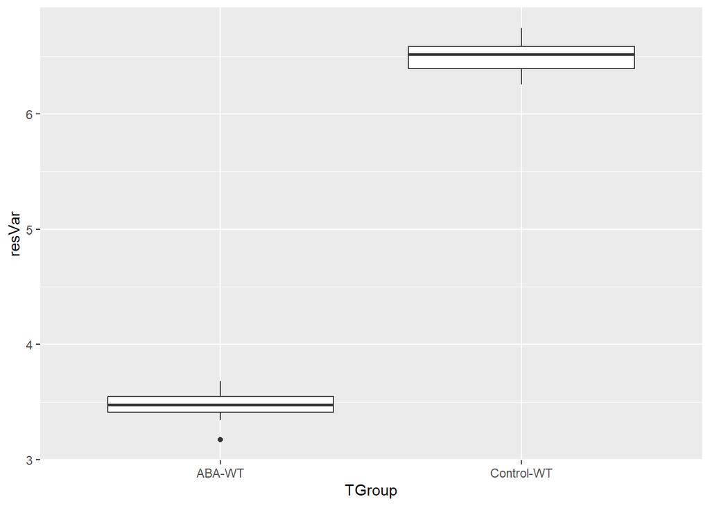

```r
#Plotting ANOVA data

  ANOplot <- ggplot(data=ANOdata,aes(x=TGroup, y=resVar, FILL=TGroup)) +
             geom_boxplot()
  print(ANOplot)
```

```r
#Modeling ANOVA data

  ANOmodel <- aov(resVar~TGroup, data = ANOdata)
  print(ANOmodel)
```

```
## Call:
##    aov(formula = resVar ~ TGroup, data = ANOdata)
##
## Terms:
##                    TGroup Residuals
## Sum of Squares  136.90798   0.92069
## Deg. of Freedom         1        58
##
## Residual standard error: 0.1259919
## Estimated effects may be unbalanced
```

```r
  print(summary(ANOmodel))
```

```
##             Df Sum Sq Mean Sq F value Pr(>F)
## TGroup       1 136.91  136.91    8625 <2e-16 ***
## Residuals   58   0.92    0.02
## ---
## Signif. codes:  0 '***' 0.001 '**' 0.01 '*' 0.05 '.' 0.1 ' ' 1
```

```r
  z <- summary(ANOmodel)
  aggregate(resVar~TGroup,data=ANOdata,FUN = mean)
```

```
##       TGroup   resVar
## 1     ABA-WT 3.474991
## 2 Control-WT 6.496117
```

```r
  #unlist(z)
  #z
  #unlist(z)[7]
  ANOsum <- list(Fval = unlist(z)[7],
                 probF = unlist(z)[9])
  ANOsum
```

```
## $Fval
## F value1
## 8624.689
##
## $probF
##      Pr(>F)1
## 8.673605e-65
```

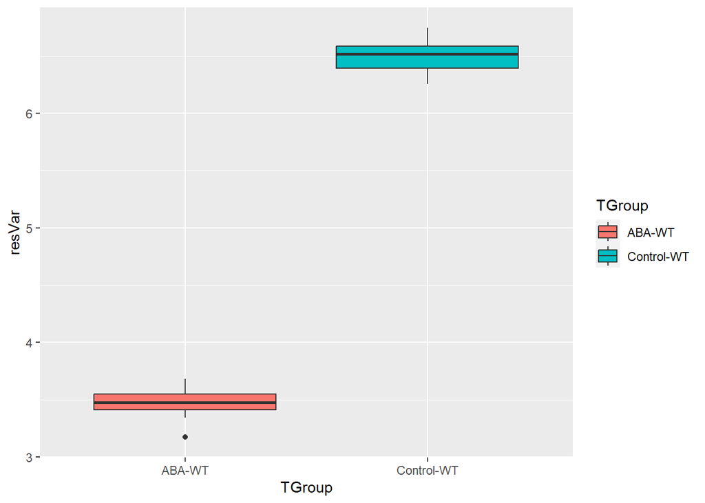

```r
#Basic ggplot of ANOVA data

  ANOPlot <- ggplot(data=ANOdata,
                    aes(x=TGroup,
                        y=resVar,
                        fill=TGroup)) +
           geom_boxplot()
  print(ANOPlot)
```

```r
# ggsave(filename="Plot2.pdf",plot=ANOPlot,device="pdf")
```

## Running analysis multiple times

# Run number 1

```r
#Run number 1

#Loading  ggplot2

  library(ggplot2)

#Number of treatment groups
  nGroup <- 2

#Name of Groups
  nName <- c("Control", "ABA")

#Number of Observations in each group
  nSize <- c(30, 30)

#Mean of each group
  nMean <- c(6.5, 3.5)

#Standard Deviation of each group
  nSD <- c(0.125, 0.125)

#ID vector for each row

  ID <- 1:(sum(nSize))
  resVar <- c(rnorm(n=nSize[1], mean=nMean[1], sd=nSD[1]),
              rnorm(n=nSize[2], mean=nMean[2], sd=nSD[2]))
  TGroup <- rep(nName, nSize)
  ANOdata <- data.frame(ID,TGroup,resVar)
  str(ANOdata)
```

```
## 'data.frame':    60 obs. of  3 variables:
##  $ ID    : int  1 2 3 4 5 6 7 8 9 10 ...
##  $ TGroup: chr  "Control" "Control" "Control" "Control" ...
##  $ resVar: num  6.36 6.57 6.39 6.55 6.73 ...
```

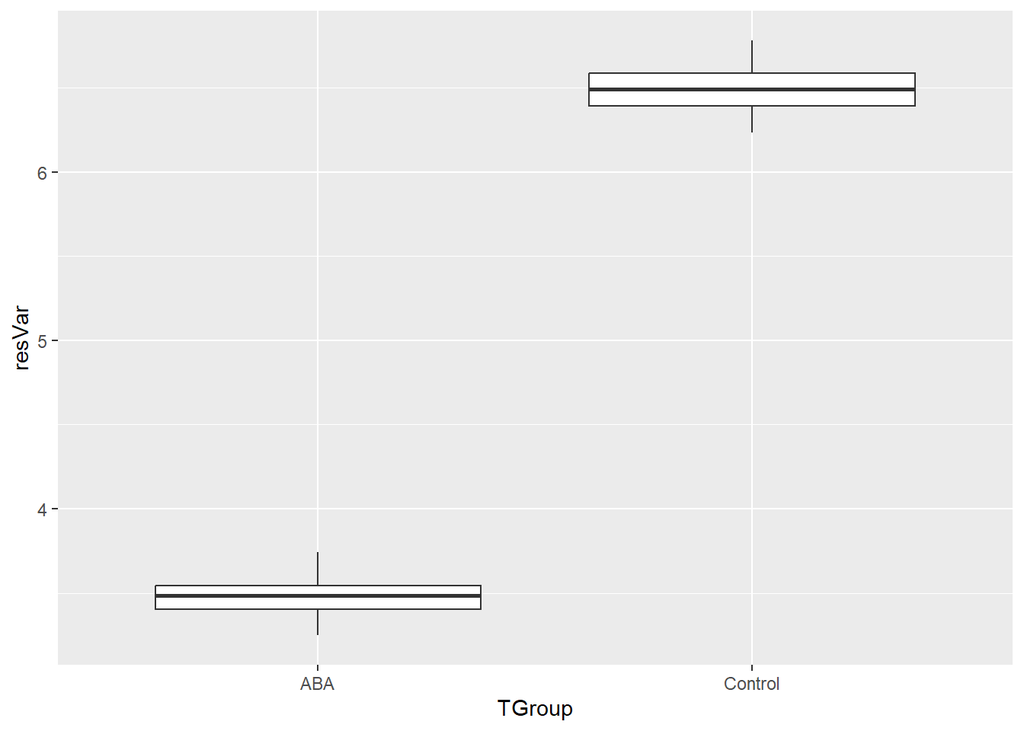

```r
#Plotting ANOVA data

  ANOplot <- ggplot(data=ANOdata,aes(x=TGroup, y=resVar, FILL=TGroup)) +
             geom_boxplot()
  print(ANOplot)
```

```r
#Modeling ANOVA data

  ANOmodel <- aov(resVar~TGroup, data = ANOdata)
  print(ANOmodel)
```

```
## Call:
##    aov(formula = resVar ~ TGroup, data = ANOdata)
##
## Terms:
##                    TGroup Residuals
## Sum of Squares  136.78725   0.91634
## Deg. of Freedom         1        58
##
## Residual standard error: 0.1256942
## Estimated effects may be unbalanced
```

```r
  print(summary(ANOmodel))
```

```
##             Df Sum Sq Mean Sq F value Pr(>F)
## TGroup       1 136.79  136.79    8658 <2e-16 ***
## Residuals   58   0.92    0.02
## ---
## Signif. codes:  0 '***' 0.001 '**' 0.01 '*' 0.05 '.' 0.1 ' ' 1
```

```r
  z <- summary(ANOmodel)
  str(z)
```

```
## List of 1
##  $ :Classes 'anova' and 'data.frame':    2 obs. of  5 variables:
##   ..$ Df     : num [1:2] 1 58
##   ..$ Sum Sq : num [1:2] 136.787 0.916
##   ..$ Mean Sq: num [1:2] 136.7872 0.0158
##   ..$ F value: num [1:2] 8658 NA
##   ..$ Pr(>F) : num [1:2] 7.76e-65 NA
##  - attr(*, "class")= chr [1:2] "summary.aov" "listof"
```

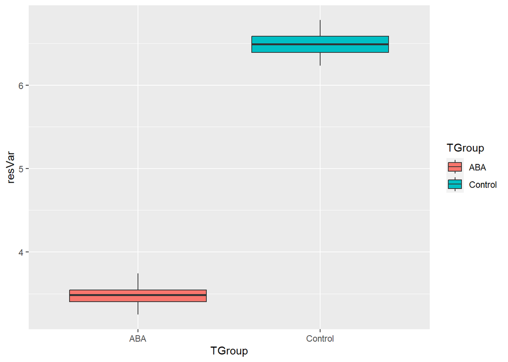

```r
#Basic ggplot of ANOVA data

  ANOPlot <- ggplot(data=ANOdata,aes(x=TGroup,y=resVar,fill=TGroup)) +
           geom_boxplot()
  print(ANOPlot)
```

```r
# ggsave(filename="Plot2.pdf",plot=ANOPlot,device="pdf")
```

# Run number 2

```r
  #Loading  ggplot2

  library(ggplot2)

#Number of treatment groups
  nGroup <- 2

#Name of Groups
  nName <- c("Control", "ABA")

#Number of Observations in each group
  nSize <- c(30, 30)

#Mean of each group
  nMean <- c(6.5, 3.5)

#Standard Deviation of each group
  nSD <- c(0.125, 0.125)

#ID vector for each row

  ID <- 1:(sum(nSize))
  resVar <- c(rnorm(n=nSize[1], mean=nMean[1], sd=nSD[1]),
              rnorm(n=nSize[2], mean=nMean[2], sd=nSD[2]))
  TGroup <- rep(nName, nSize)
  ANOdata <- data.frame(ID,TGroup,resVar)
  str(ANOdata)
```

```
## 'data.frame':    60 obs. of  3 variables:
##  $ ID    : int  1 2 3 4 5 6 7 8 9 10 ...
##  $ TGroup: chr  "Control" "Control" "Control" "Control" ...
##  $ resVar: num  6.49 6.58 6.36 6.58 6.72 ...
```

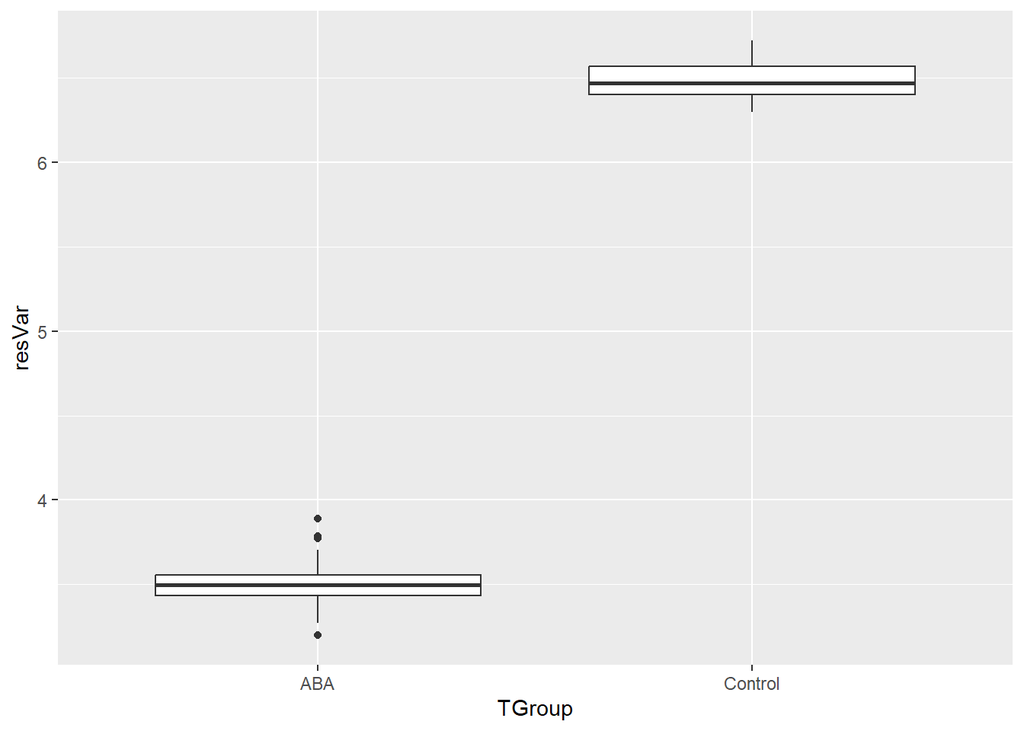

```r
#Plotting ANOVA data

  ANOplot <- ggplot(data=ANOdata,aes(x=TGroup, y=resVar, FILL=TGroup)) +
             geom_boxplot()
  print(ANOplot)
```

```r
#Modeling ANOVA data

  ANOmodel <- aov(resVar~TGroup, data = ANOdata)
  print(ANOmodel)
```

```
## Call:
##    aov(formula = resVar ~ TGroup, data = ANOdata)
##
## Terms:
##                    TGroup Residuals
## Sum of Squares  132.85880   0.98597
## Deg. of Freedom         1        58
##
## Residual standard error: 0.1303819
## Estimated effects may be unbalanced
```

```r
  print(summary(ANOmodel))
```

```
##             Df Sum Sq Mean Sq F value Pr(>F)
## TGroup       1 132.86  132.86    7815 <2e-16 ***
## Residuals   58   0.99    0.02
## ---
## Signif. codes:  0 '***' 0.001 '**' 0.01 '*' 0.05 '.' 0.1 ' ' 1
```

```r
  z <- summary(ANOmodel)
  str(z)
```

```
## List of 1
##  $ :Classes 'anova' and 'data.frame':    2 obs. of  5 variables:
##   ..$ Df     : num [1:2] 1 58
##   ..$ Sum Sq : num [1:2] 132.859 0.986
##   ..$ Mean Sq: num [1:2] 132.859 0.017
##   ..$ F value: num [1:2] 7815 NA
##   ..$ Pr(>F) : num [1:2] 1.48e-63 NA
##  - attr(*, "class")= chr [1:2] "summary.aov" "listof"
```

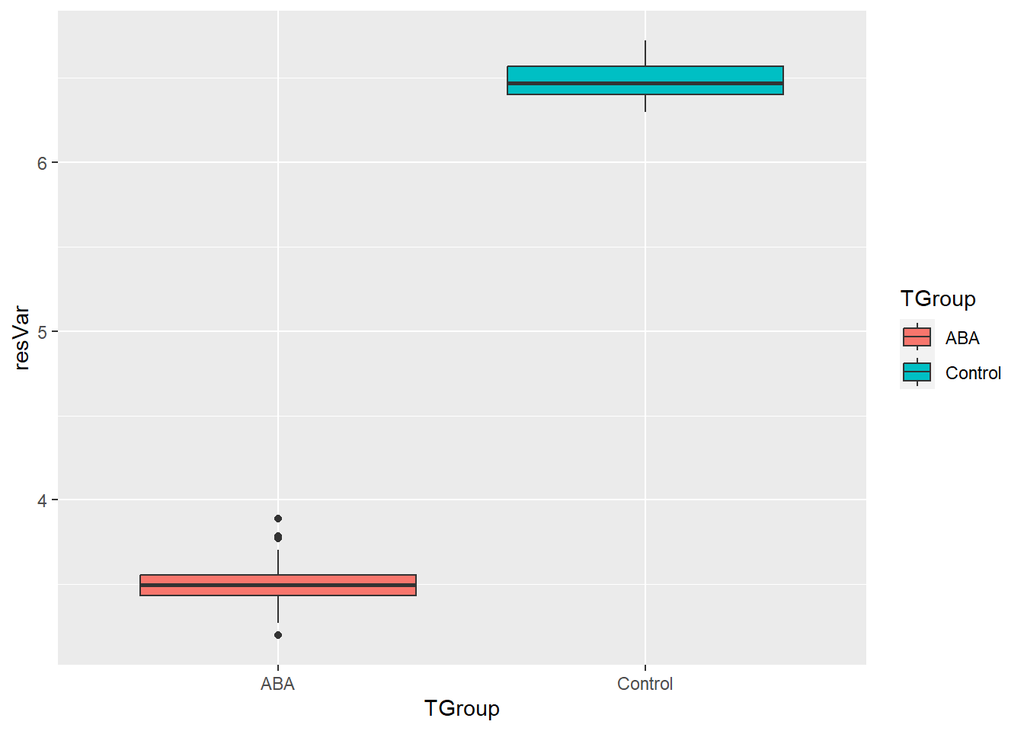

```r
#Basic ggplot of ANOVA data

  ANOPlot <- ggplot(data=ANOdata,aes(x=TGroup,y=resVar,fill=TGroup)) +
           geom_boxplot()
  print(ANOPlot)
```

```r
# ggsave(filename="Plot2.pdf",plot=ANOPlot,device="pdf")
```

# Run Number 3

```r
  #Loading  ggplot2

  library(ggplot2)

#Number of treatment groups
  nGroup <- 2

#Name of Groups
  nName <- c("Control", "ABA")

#Number of Observations in each group
  nSize <- c(30, 30)

#Mean of each group
  nMean <- c(6.5, 3.5)

#Standard Deviation of each group
  nSD <- c(0.125, 0.125)

#ID vector for each row

  ID <- 1:(sum(nSize))
  resVar <- c(rnorm(n=nSize[1], mean=nMean[1], sd=nSD[1]),
              rnorm(n=nSize[2], mean=nMean[2], sd=nSD[2]))
  TGroup <- rep(nName, nSize)
  ANOdata <- data.frame(ID,TGroup,resVar)
  str(ANOdata)
```

```
## 'data.frame':    60 obs. of  3 variables:
##  $ ID    : int  1 2 3 4 5 6 7 8 9 10 ...
##  $ TGroup: chr  "Control" "Control" "Control" "Control" ...
##  $ resVar: num  6.55 6.49 6.42 6.47 6.43 ...
```

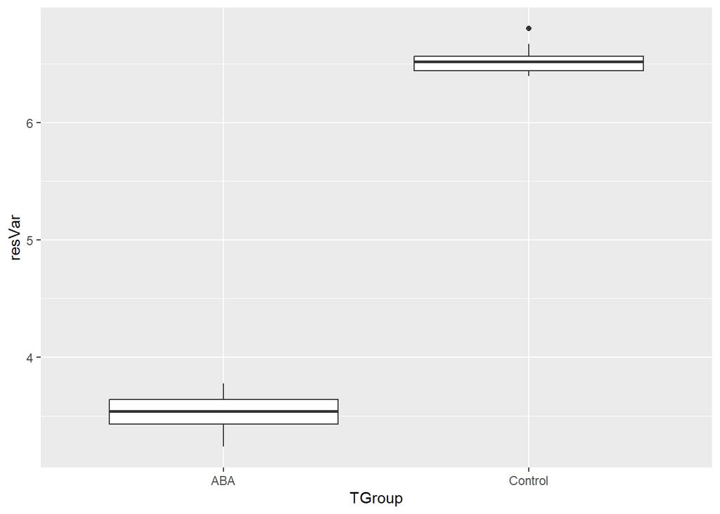

```r
#Plotting ANOVA data

  ANOplot <- ggplot(data=ANOdata,aes(x=TGroup, y=resVar, FILL=TGroup)) +
             geom_boxplot()
  print(ANOplot)
```

```r
#Modeling ANOVA data

  ANOmodel <- aov(resVar~TGroup, data = ANOdata)
  print(ANOmodel)
```

```
## Call:
##    aov(formula = resVar ~ TGroup, data = ANOdata)
##
## Terms:
##                    TGroup Residuals
## Sum of Squares  134.96206   0.76502
## Deg. of Freedom         1        58
##
## Residual standard error: 0.1148478
## Estimated effects may be unbalanced
```

```r
  print(summary(ANOmodel))
```

```
##             Df Sum Sq Mean Sq F value Pr(>F)
## TGroup       1 134.96  134.96   10232 <2e-16 ***
## Residuals   58   0.77    0.01
## ---
## Signif. codes:  0 '***' 0.001 '**' 0.01 '*' 0.05 '.' 0.1 ' ' 1
```

```r
  z <- summary(ANOmodel)
  str(z)
```

```
## List of 1
##  $ :Classes 'anova' and 'data.frame':    2 obs. of  5 variables:
##   ..$ Df     : num [1:2] 1 58
##   ..$ Sum Sq : num [1:2] 134.962 0.765
##   ..$ Mean Sq: num [1:2] 134.9621 0.0132
##   ..$ F value: num [1:2] 10232 NA
##   ..$ Pr(>F) : num [1:2] 6.29e-67 NA
##  - attr(*, "class")= chr [1:2] "summary.aov" "listof"
```

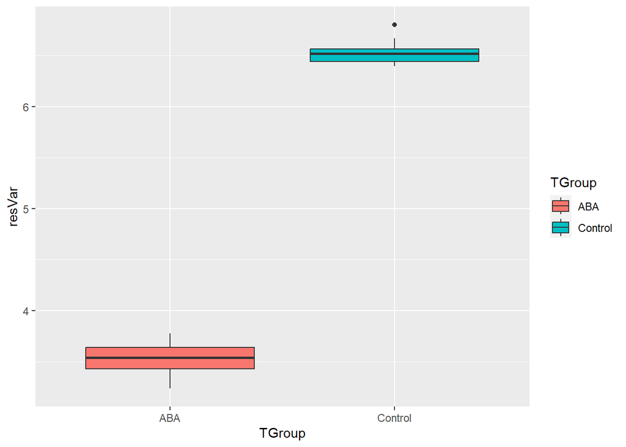

```r
#Basic ggplot of ANOVA data

  ANOPlot <- ggplot(data=ANOdata,aes(x=TGroup,y=resVar,fill=TGroup)) +
           geom_boxplot()
  print(ANOPlot)
```

```r
# ggsave(filename="Plot2.pdf",plot=ANOPlot,device="pdf")
```

## Trying out different means and differences between the groups

# Testing difference of 1

```r
#Loading  ggplot2

  library(ggplot2)

#Number of treatment groups
  nGroup <- 2

#Name of Groups
  nName <- c("Control", "ABA")

#Number of Observations in each group
  nSize <- c(30, 30)

#Mean of each group
  nMean <- c(6.5, 5.5)

#Standard Deviation of each group
  nSD <- c(0.125, 0.125)

#ID vector for each row

  ID <- 1:(sum(nSize))
  resVar <- c(rnorm(n=nSize[1], mean=nMean[1], sd=nSD[1]),
              rnorm(n=nSize[2], mean=nMean[2], sd=nSD[2]))
  TGroup <- rep(nName, nSize)
  ANOdata <- data.frame(ID,TGroup,resVar)
  str(ANOdata)
```

```
## 'data.frame':    60 obs. of  3 variables:
##  $ ID    : int  1 2 3 4 5 6 7 8 9 10 ...
##  $ TGroup: chr  "Control" "Control" "Control" "Control" ...
##  $ resVar: num  6.57 6.65 6.6 6.22 6.43 ...
```

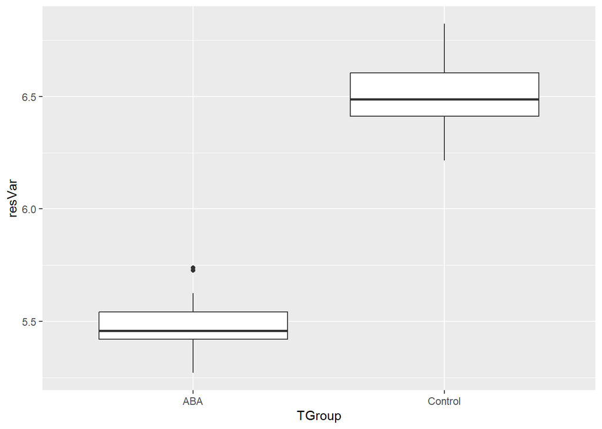

```r
#Plotting ANOVA data

  ANOplot <- ggplot(data=ANOdata,aes(x=TGroup, y=resVar, FILL=TGroup)) +
             geom_boxplot()
  print(ANOplot)
```

```r
#Modeling ANOVA data

  ANOmodel <- aov(resVar~TGroup, data = ANOdata)
  print(ANOmodel)
```

```
## Call:
##    aov(formula = resVar ~ TGroup, data = ANOdata)
##
## Terms:
##                    TGroup Residuals
## Sum of Squares  15.714811  0.921265
## Deg. of Freedom         1        58
##
## Residual standard error: 0.1260313
## Estimated effects may be unbalanced
```

```r
  print(summary(ANOmodel))
```

```
##             Df Sum Sq Mean Sq F value Pr(>F)
## TGroup       1 15.715  15.715   989.4 <2e-16 ***
## Residuals   58  0.921   0.016
## ---
## Signif. codes:  0 '***' 0.001 '**' 0.01 '*' 0.05 '.' 0.1 ' ' 1
```

```r
  z <- summary(ANOmodel)
  str(z)
```

```
## List of 1
##  $ :Classes 'anova' and 'data.frame':    2 obs. of  5 variables:
##   ..$ Df     : num [1:2] 1 58
##   ..$ Sum Sq : num [1:2] 15.715 0.921
##   ..$ Mean Sq: num [1:2] 15.7148 0.0159
##   ..$ F value: num [1:2] 989 NA
##   ..$ Pr(>F) : num [1:2] 3.86e-38 NA
##  - attr(*, "class")= chr [1:2] "summary.aov" "listof"
```

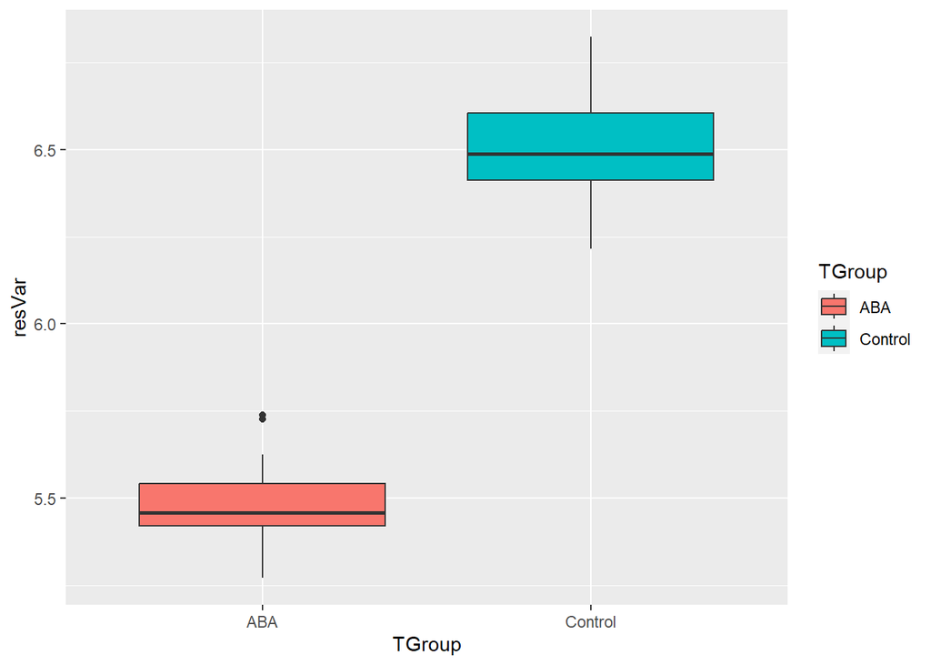

```r
#Basic ggplot of ANOVA data

  ANOPlot <- ggplot(data=ANOdata,aes(x=TGroup,y=resVar,fill=TGroup)) +
           geom_boxplot()
  print(ANOPlot)
```

```r
# ggsave(filename="Plot2.pdf",plot=ANOPlot,device="pdf")
```

# Testing difference of 0.5

```r
#Loading  ggplot2

  library(ggplot2)

#Number of treatment groups
  nGroup <- 2

#Name of Groups
  nName <- c("Control", "ABA")

#Number of Observations in each group
  nSize <- c(30, 30)

#Mean of each group
  nMean <- c(6.5, 6)

#Standard Deviation of each group
  nSD <- c(0.125, 0.125)

#ID vector for each row

  ID <- 1:(sum(nSize))
  resVar <- c(rnorm(n=nSize[1], mean=nMean[1], sd=nSD[1]),
              rnorm(n=nSize[2], mean=nMean[2], sd=nSD[2]))
  TGroup <- rep(nName, nSize)
  ANOdata <- data.frame(ID,TGroup,resVar)
  str(ANOdata)
```

```
## 'data.frame':    60 obs. of  3 variables:
##  $ ID    : int  1 2 3 4 5 6 7 8 9 10 ...
##  $ TGroup: chr  "Control" "Control" "Control" "Control" ...
##  $ resVar: num  6.46 6.41 6.36 6.42 6.72 ...
```

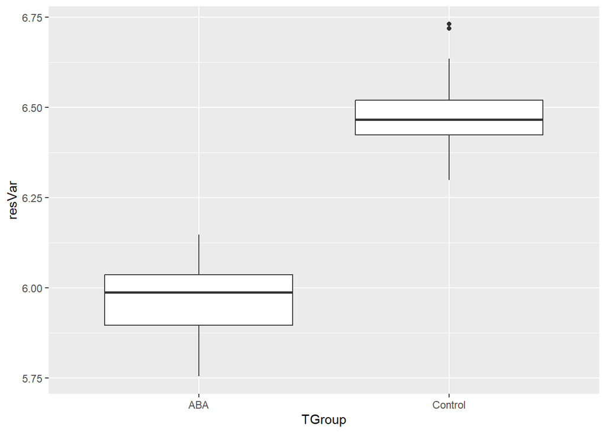

```r
#Plotting ANOVA data

  ANOplot <- ggplot(data=ANOdata,aes(x=TGroup, y=resVar, FILL=TGroup)) +
             geom_boxplot()
  print(ANOplot)
```

```r
#Modeling ANOVA data

  ANOmodel <- aov(resVar~TGroup, data = ANOdata)
  print(ANOmodel)
```

```
## Call:
##    aov(formula = resVar ~ TGroup, data = ANOdata)
##
## Terms:
##                   TGroup Residuals
## Sum of Squares  3.928271  0.619338
## Deg. of Freedom        1        58
##
## Residual standard error: 0.1033356
## Estimated effects may be unbalanced
```

```r
  print(summary(ANOmodel))
```

```
##             Df Sum Sq Mean Sq F value Pr(>F)
## TGroup       1  3.928   3.928   367.9 <2e-16 ***
## Residuals   58  0.619   0.011
## ---
## Signif. codes:  0 '***' 0.001 '**' 0.01 '*' 0.05 '.' 0.1 ' ' 1
```

```r
  z <- summary(ANOmodel)
  str(z)
```

```
## List of 1
##  $ :Classes 'anova' and 'data.frame':    2 obs. of  5 variables:
##   ..$ Df     : num [1:2] 1 58
##   ..$ Sum Sq : num [1:2] 3.928 0.619
##   ..$ Mean Sq: num [1:2] 3.9283 0.0107
##   ..$ F value: num [1:2] 368 NA
##   ..$ Pr(>F) : num [1:2] 8.69e-27 NA
##  - attr(*, "class")= chr [1:2] "summary.aov" "listof"
```

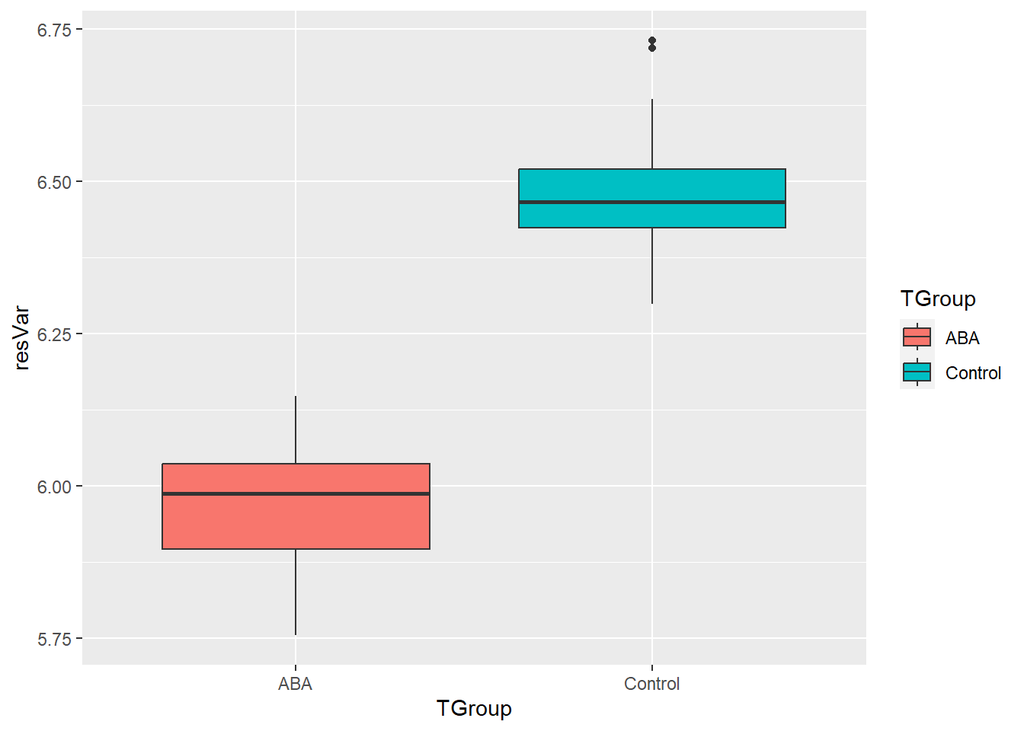

```r
#Basic ggplot of ANOVA data

  ANOPlot <- ggplot(data=ANOdata,aes(x=TGroup,y=resVar,fill=TGroup)) +
           geom_boxplot()
  print(ANOPlot)
```

```r
# ggsave(filename="Plot2.pdf",plot=ANOPlot,device="pdf")
```

# Testing difference of 0.05

```r
#Loading  ggplot2

  library(ggplot2)

#Number of treatment groups
  nGroup <- 2

#Name of Groups
  nName <- c("Control", "ABA")

#Number of Observations in each group
  nSize <- c(30, 30)

#Mean of each group
  nMean <- c(6.5, 6.45)

#Standard Deviation of each group
  nSD <- c(0.125, 0.125)

#ID vector for each row

  ID <- 1:(sum(nSize))
  resVar <- c(rnorm(n=nSize[1], mean=nMean[1], sd=nSD[1]),
              rnorm(n=nSize[2], mean=nMean[2], sd=nSD[2]))
  TGroup <- rep(nName, nSize)
  ANOdata <- data.frame(ID,TGroup,resVar)
  str(ANOdata)
```

```
## 'data.frame':    60 obs. of  3 variables:
##  $ ID    : int  1 2 3 4 5 6 7 8 9 10 ...
##  $ TGroup: chr  "Control" "Control" "Control" "Control" ...
##  $ resVar: num  6.58 6.68 6.69 6.65 6.5 ...
```

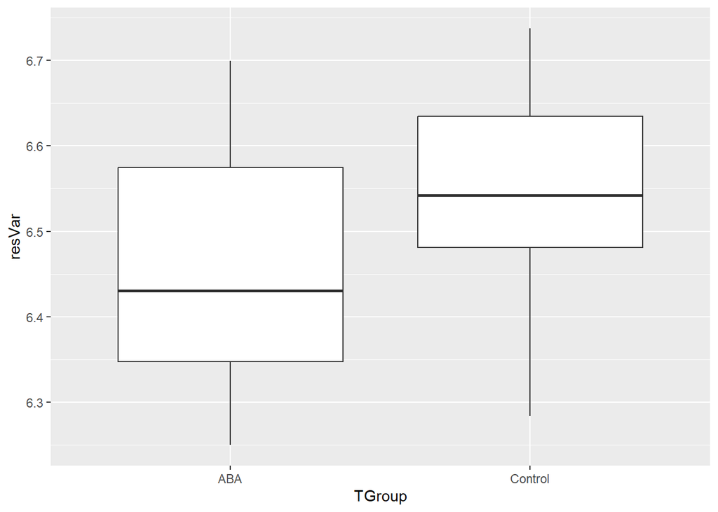

```r
#Plotting ANOVA data

  ANOplot <- ggplot(data=ANOdata,aes(x=TGroup, y=resVar, FILL=TGroup)) +
             geom_boxplot()
  print(ANOplot)
```

```r
#Modeling ANOVA data

  ANOmodel <- aov(resVar~TGroup, data = ANOdata)
  print(ANOmodel)
```

```
## Call:
##    aov(formula = resVar ~ TGroup, data = ANOdata)
##
## Terms:
##                    TGroup Residuals
## Sum of Squares  0.1221470 0.8466163
## Deg. of Freedom         1        58
##
## Residual standard error: 0.1208174
## Estimated effects may be unbalanced
```

```r
  print(summary(ANOmodel))
```

```
##             Df Sum Sq Mean Sq F value  Pr(>F)
## TGroup       1 0.1221  0.1221   8.368 0.00537 **
## Residuals   58 0.8466  0.0146
## ---
## Signif. codes:  0 '***' 0.001 '**' 0.01 '*' 0.05 '.' 0.1 ' ' 1
```

```r
  z <- summary(ANOmodel)
  str(z)
```

```
## List of 1
##  $ :Classes 'anova' and 'data.frame':    2 obs. of  5 variables:
##   ..$ Df     : num [1:2] 1 58
##   ..$ Sum Sq : num [1:2] 0.122 0.847
##   ..$ Mean Sq: num [1:2] 0.1221 0.0146
##   ..$ F value: num [1:2] 8.37 NA
##   ..$ Pr(>F) : num [1:2] 0.00537 NA
##  - attr(*, "class")= chr [1:2] "summary.aov" "listof"
```

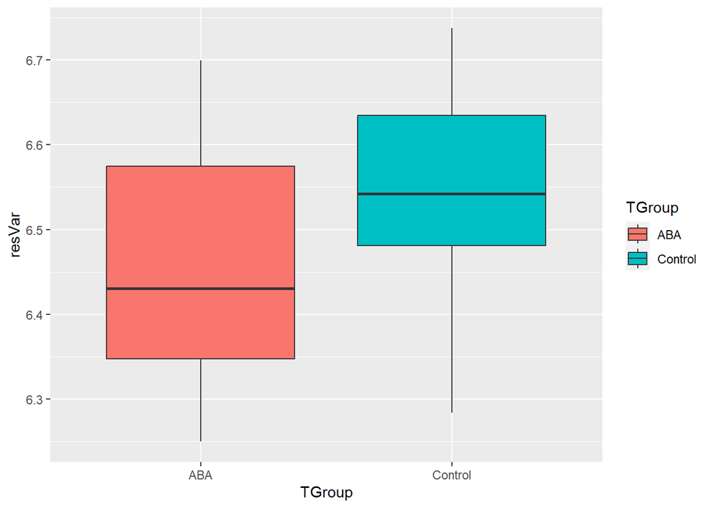

```r
#Basic ggplot of ANOVA data

  ANOPlot <- ggplot(data=ANOdata,aes(x=TGroup,y=resVar,fill=TGroup)) +
           geom_boxplot()
  print(ANOPlot)
```

```r
# ggsave(filename="Plot2.pdf",plot=ANOPlot,device="pdf")
```